# index

## Introduction to Data Science: Final Tutorial

**Introduction:**

**Required Libraries**

- gmaps
- pandas
- matplotlib.pyplot
- seaborn
- numpy
- urllib.request
- json
- ipywidgets
- IPython
- literal_eval
- sklearn

**Part 1: Data collection**

```python
#Installing and enabling widgets
%%capture
!pip install gmaps
!pip install jupyter_contrib_nbextensions
!pip install ipywidgets
!jupyter contrib nbextension install --user
!jupyter nbextension enable --py gmaps
!jupyter nbextension enable --py --sys-prefix widgetsnbextension
```

```python
#Imports
from google.colab import output
from datetime import datetime
output.enable_custom_widget_manager()
import pandas as pd
import matplotlib.pyplot as plt
import seaborn as sns
import numpy as np
import urllib.request
import json
import gmaps
import gmaps.datasets
import ipywidgets as widgets
from ipywidgets.embed import embed_minimal_html
import IPython
import gmaps.geojson_geometries
from ast import literal_eval
from sklearn.preprocessing import PolynomialFeatures
from sklearn import linear_model
```

**Part Two: Data Cleaning** \ We need to clean up the CSV file to make it easier to work with throughout this project. We will preform the following steps to take

1. Read the CSV file and put it into a pandas data frame, so we can work with it and manipulate the file in a table (read more about Pandas here: https://pandas.pydata.org/).
2. Analyze what columns we want to work with for this project and drop unused columns to make the dataframe easier to work with.
3. Drop rows with (N/A) data, and rows with without a location because location is an essential column in this project.
4. Convert the location column in to a tuple, so it can be used easier

```python
#Download the CSV file of Montgomery County Crime Data
#via this website and open as a Pandas Dataframe https://data.montgomerycountymd.gov/Public-Safety/Crime/icn6-v9z3
df = pd.read_csv('https://raw.githubusercontent.com/briforreal/briforreal.github.io/main/Crime.csv')
# dropped columns with majorty missing data, dropped columns with redundant information
df = df.drop(columns = ['State', 'Street Prefix', 'Street Suffix','NIBRS Code', 'Offence Code', 'CR Number', 'Crime Name1',
       'Crime Name3',  'Sector' , 'Address Number', 'Street Name', 'Street Type', 'Incident ID', 'Dispatch Date / Time', 'Victims', 'Police District Name', 'Block Address', 'Zip Code', 'Agency' , 'Beat', 'PRA', 'Latitude',
       'Longitude', 'Police District Number'])
# dropped rows with missing information
df = df.dropna()
# drop rows with out location information
df = df[df['Location'] != '(0.0, 0.0)']
df['Location'] = df['Location'].apply(lambda loc: literal_eval(str(loc)))
df.rename(columns= {'Crime Name2': 'Crime'}, inplace=True)
```

We are creating a time of day column to make easier when we preform analysis on the relationship between time and day and time. \ To do this, we first convert the start date time and end date time columns into strings and then convert each time into a datetime type to make it easier to work with.

```python
# adding time of day columns based of start time
# Morning 6 am to 11:59 am
# Afternoon 12 pm to 5:59 pm
# Evening  6 pm to 11:59 pm
# Night  12 am to 5:59 am
df['Start_Date_Time'] = df['Start_Date_Time'].astype(str)
df['Start_Date_Time'] = pd.to_datetime(df['Start_Date_Time'])
df['End_Date_Time'] = df['End_Date_Time'].astype(str)
df['End_Date_Time'] = pd.to_datetime(df['End_Date_Time'])
```

Next we create bins of the time cutoffs, labels for the corresponding time. Then convert the start_date_time column into a time delta. Then use cut to give each start time the correct time label into a new column called time_day

```python
bins = ['00:00:00', '05:59:00', '11:59:00', '17:59:00', '23:59:00']
labels = ['Night', 'Morning', 'Afternoon', 'Evening']
s = pd.to_timedelta(pd.to_datetime(df['Start_Date_Time']).dt.time.astype(str))
df['time_day'] = pd.cut(s, bins=pd.to_timedelta(bins), labels=labels, ordered=False)
```

**Part 3: Data Analysis**

To get an overview on some of the crime related variables, we created bar graphs that show the top ten variable vs the number of crimes. \ To create the bar graphs, we need to create an array of all the columns we want to see the frequency information visually. Then iterate over the array of column names and find the top ten of each column and the total count and put into a new dataframe. With the new dataframe we will use it to create a bar graph with seaborn.

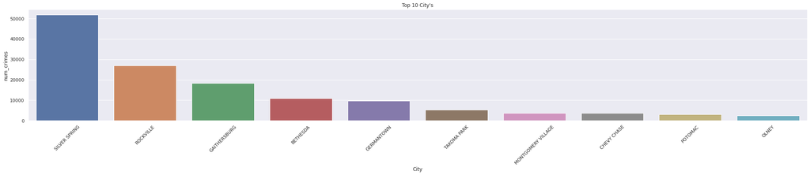

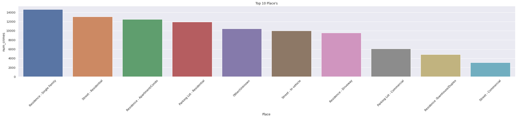

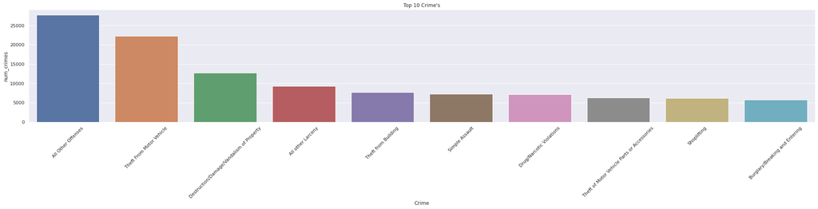

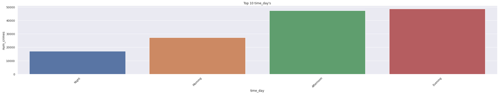

```python
#top 10 crime related variables vs number of crimes bar graphs to see the frequency information visually
array = ['City', 'Place', 'Crime', 'time_day']
for arr in array:
  plt.figure()
  city_freq = df[arr].value_counts().nlargest(10).rename_axis(arr).reset_index(name='num_crimes')
  sns.set(rc={"figure.figsize":(34, 5)})
  plt.xticks(rotation=45)
  sns.barplot(x = arr, y = 'num_crimes',data = city_freq).set(title='Top 10 {}\'s'.format(arr))
```

**Analyzing the Top 10 Bar Graphs**

1. City vs Total Crime: The top ten city are also some of the most populated cities, so it makes sense that most of the crimes committed take place there
2. Place vs Total Crime: Home burglary and other house related crimes are common, so it makes sense most places are residential.
3. Type of Crime vs Total Crime: Car theft and other auto related crimes are common within Montgomery County, this should be told to residents to allow them to secure their cars accordingly
4. Time of Crime vs Total Crime: Most of the crime taking place during the afternoon and evening makes sense due to people being out of their homes during the afternoon, this also means residents should be more diligent and alert during these times.

**Creating a Heat Map of crime in Montgomery County**

We will use the gmaps api to create a heat map of crime in Montgomery County.

1. We need to first create google maps api key
2. Then I created a Montgomery county boundary geo json file to help visualize the boundaries easier. Import the file and add it as a geo json layer to the map.
3. Create a google map that is centered in Montgomery county and zoom it in to get a good view
4. Add all the locations in the dataframe into an array by iterating over the locations column in the dataframe
5. add the locations to the heatmap_layer and then add that layer to the map

```python
from gmaps import locations
# Creating a map of mongomery county
gmaps.configure(api_key = 'AIzaSyDfoX1MPWaOHwG3hEWAGiprM7e9HjG-dqM')
# created a geojson file of the mongomery county boundries based of nominatim.openstreetmap.org
with urllib.request.urlopen("https://raw.githubusercontent.com/briforreal/briforreal.github.io/main/moco.json") as url:
    geometry = json.load(url)
moco_coordinates = (39.1547, -77.2405)
fig = gmaps.figure(center=moco_coordinates, zoom_level=10)
geojson_layer = gmaps.geojson_layer(geometry, fill_color='red',
stroke_color='red')
fig.add_layer(geojson_layer)
locations = []
for i in df.index:
  locations.append(df.at[i, 'Location'])
fig.add_layer(gmaps.heatmap_layer(locations))
```

[figure not shown]

**Analyzing the Heat Map** \ The heat map reflects Crime vs Total crime bar graphs, we can see that most of the crime is committed in cities and as you get to more rural places in the county there is less crime. Knowing that there is a density of crime in cities allows Montgomery County police to allocate their patrol resources accordingly.

```python
# Seing if there is a relationship between time of day and place
top_place = df[df['Place'] != 'Other/Unknown']
top_place = top_place[top_place['Place'].isin(top_place['Place'].value_counts().head(10).index)]
place_array = np.array(top_place['Place'].unique().tolist())
time_array = np.array(['Night', 'Morning', 'Afternoon', 'Evening'])
```

The next step of our data analysis we wanted to look at the relationship between top 5 crimes in Montgomery county and what season they peak in. To do that, we want to create a column in our dataframe that assigns a season to the crime based on the date it occured.

```python
#Creating a seasonal graph to see top crimes in each season
#Start by making a column for seasons
seasons = []
for i in df.index:
  #using the month attribute of the datetime object to assign a season
  month = df["Start_Date_Time"][i].month
  if (month == 12) | (month == 1 )| (month == 2):
    seasons.append("winter")
  elif (month == 3) | (month == 4)| (month == 5):
    seasons.append("spring")
  elif (month == 6) | (month == 7)| (month == 8):
    seasons.append("summer")
  else:
    seasons.append("fall")
#use list to assign new column in the dataframe
df["Season"] = seasons
```

**Season & Crime Histogram**

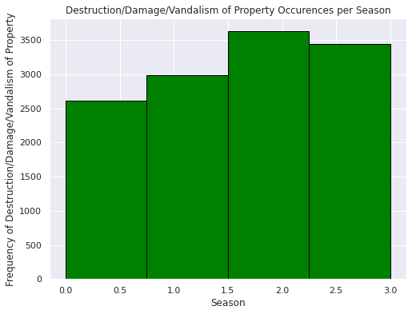

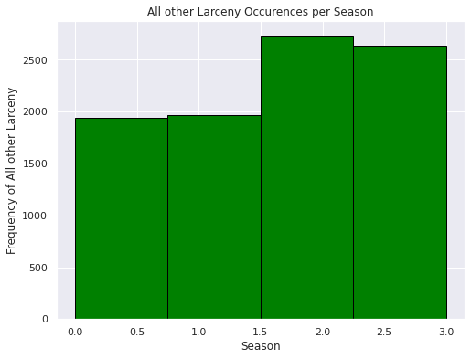

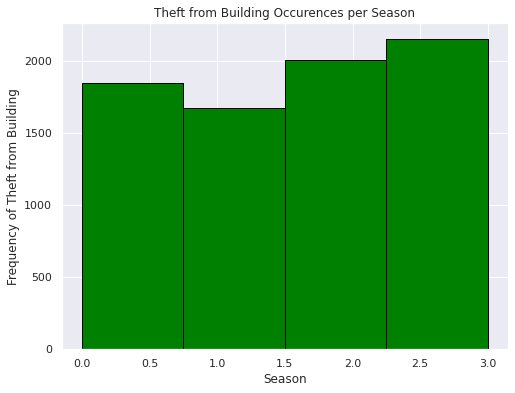

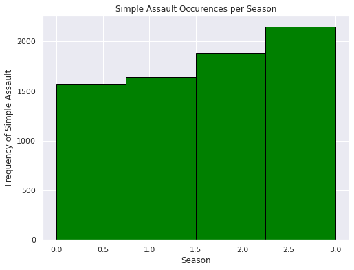

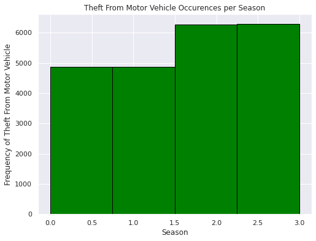

```python
#import figure from matplotlib to modify the size of the graphs
from matplotlib.pyplot import figure

#list of top five crimes
top_5_crimes = ["Destruction/Damage/Vandalism of Property", "All other Larceny", "Theft from Building", "Simple Assault", "Theft From Motor Vehicle"]
summer_counter = 0
spring_counter = 0
winter_counter = 0
fall_counter = 0
#dictionary of top five crimes and an array to store the seasons they occur
type_season = {"Destruction/Damage/Vandalism of Property":[], "All other Larceny":[], "Theft from Building":[], "Simple Assault":[], "Theft From Motor Vehicle":[]}
#iterates through dataframe and if crime is in type five we append
#the season to the appropiate part of the dictionary represented as an integer
for i in df.index:
  if df["Crime"][i] in top_5_crimes:
    if df["Season"][i] == "winter":
      type_season[df["Crime"][i]].append(0)
    elif df["Season"][i] == "spring":
      type_season[df["Crime"][i]].append(1)
    elif df["Season"][i] == "summer":
      type_season[df["Crime"][i]].append(2)
    else:
      type_season[df["Crime"][i]].append(3)

#for each top 5 crimes we create a histogram based on the season counts
for i in top_5_crimes:
  figure(figsize=(8, 6))
  hist, bin_edges = np.histogram(type_season[i], bins=4)

  #Use matplotlib to create the histogram with a bin for each season
  plt.hist(type_season[i],bins=4,color="green",edgecolor='black', linewidth=1)
  plt.ylabel("Frequency of " + i)
  plt.xlabel("Season")
  plt.title(i + " Occurences per Season")
  plt.show()
```

**Histogram Analysis**

Based on the histogram, we can see during which season each of the top 5 crimes peaks. Destruction of property, larceny, charges peak in the summer which makes sense because students are out of school. Theft both from buildings and automotives and simple assault peaks during fall.

**Season and Time of Day Analysis**

For our final data analysis on season and crime, we want to identify during what time of day crime peaks. To accomplish this we will create a bar graph and use the dataframe's "time_day" column to determine peak crime times. Follow along to learn how:

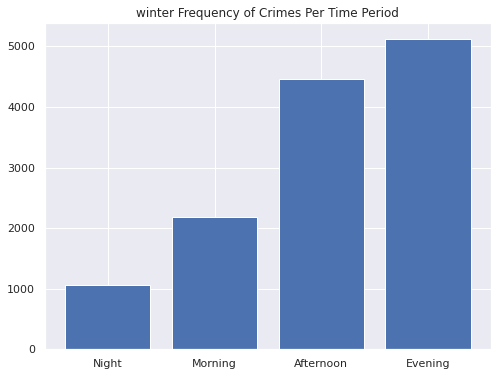

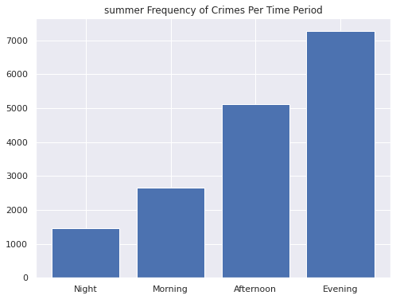

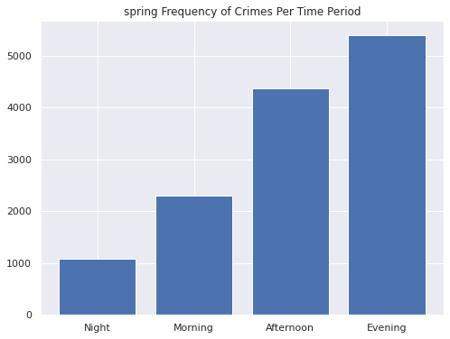

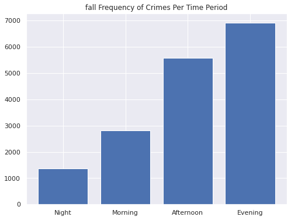

```python
#Season and time of crime
#dictionary for the counts of times per season
season_time = {"winter":[], "summer":[], "spring":[], "fall":[]}

#iterate through index noting time of day for each season
for i in df.index:
  if df["Crime"][i] in top_5_crimes:
    if df["Season"][i] == "winter":
      season_time["winter"].append(df["time_day"][i])
    elif df["Season"][i] == "spring":
      season_time["spring"].append(df["time_day"][i])
    elif df["Season"][i] == "summer":
      season_time["summer"].append(df["time_day"][i])
    else:
      season_time["fall"].append(df["time_day"][i])
labels = ["Night", "Morning", "Afternoon", "Evening"]

#iterate through each season
for i in season_time.keys():
  night_count = 0
  morning_count = 0
  afternoon_count = 0
  evening_count = 0
  lst = season_time[i]

  #count time of day for each type of time_of day
  for y in lst:
    if y == "Night":
      night_count+=1
    elif y == "Morning":
      morning_count+=1
    elif y == "Afternoon":
      afternoon_count+=1
    else:
      evening_count+=1

  #make a bar graph with the counts of each time of day using matplotlib
  figure(figsize=(8, 6))
  plt.bar(labels, [night_count, morning_count, afternoon_count, evening_count])
  plt.title(i + " Frequency of Crimes Per Time Period")
  plt.show()
```

**Bar Graph Analysis**

Creating the bar graphs involved using the matplotlib library and building dictionaries with the data we extracted. Based on the bar graphs, we see that the highest frequency of crime consistently occurs during the evenings and the second highest in the afternoons.

**Part 4: Machine Learning Analysis**

To conclude our analysis of this data set, we wanted to use a linear regression model to predict the frequency of a crime depending on the year.

A linear regression model is used to find relationships between two variables and create a best fit line modeling that relationship. Then that line is used to predict future values. To read more about linear regression and using linear regression for machine learning look here: https://www.analyticsvidhya.com/blog/2021/05/all-you-need-to-know-about-your-first-machine-learning-model-linear-regression/#:~:text=of%20Unsupervised%20ML.-,Understanding%20Linear%20Regression,the%20dependent%20and%20independent%20variable.

We use the sklearn library's linear regression function to compare the relationship between the year and frequency of a crime. Follow along below to learn the steps:

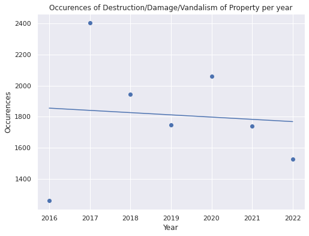

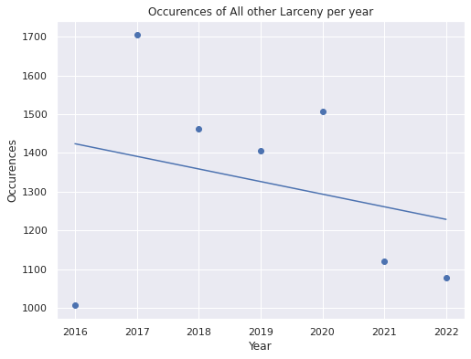

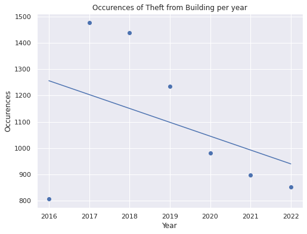

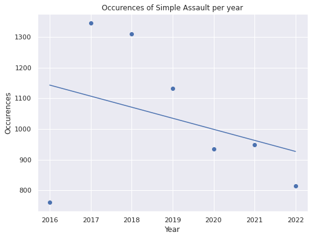

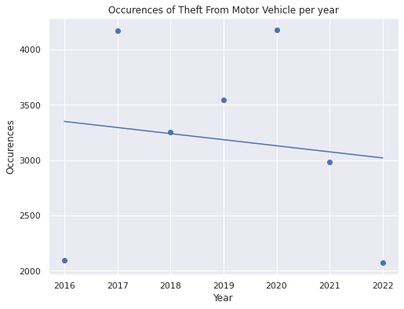

```python
#We want to use a linear regression model to predict crimes over years
for i in top_5_crimes:
  temp_df = df[df["Crime"] == i]
  year_lst = []
  count_lst = []
  year_list = []
  #find the list of years for the dataframe with the current crime
  for x in temp_df.index:
    if temp_df["Start_Date_Time"][x].year not in year_lst:
      year_lst.append(temp_df["Start_Date_Time"][x].year)

  year_lst.sort()
  #for every year append the frequency of the crime in that year
  for c in year_lst:
    counter = 0
    for y in temp_df.index:
      if temp_df["Start_Date_Time"][y].year == c:
        counter+=1
    count_lst.append(counter)
    year_list.append([int(c)])



  model = linear_model.LinearRegression()
  model.fit(year_list,count_lst)
  #create the predicted line and graph it over a scatter plot of the frequencies
  predicted = model.predict(year_list)

  figure(figsize=(8, 6))
  plt.scatter(year_lst,count_lst)
  plt.plot(year_lst,predicted)
  plt.title("Occurences of " + i + " per year")
  plt.xlabel("Year")
  plt.ylabel("Occurences")
  plt.show()
```

**Linear Regression Analysis**

The linear regression's .fit() function creates the line we use to predict the crimes freqeuency's in future years. We display this by graphing the predicted function along with the actual data points to show how the line fitted to it's given data.

**Part 5: Conclusion and Insight**

Our analysis of Montgomery County crime data will help future policy decision of Montgomery County police. The bar graphs can help the police determine trends in city, place, type of crime, and time of day. The heat map graph gives a visualization on the areas with the most crime, allowing officers to understand in what location a crime is most likely to happen. The seasonal graphs are can assist police policy in several ways. The graph comparing frequency of crime during a season will allow police to know during which seasons to look for uptick of certain crimes and warn citizens accordingly. The graph showing the frequency of crimes during a certain time per season allow police to know when to send out more patrols per each season. After concluding our various data analysis, we conducted linear regression between the top five crimes and the year so that we could predict the frequency of a crime every year. In the future, we could feed the linear regressor more data, so it would be better trained at predicting. We could also use other machine learning algorithms such as KNN or polyregression.